# WaterLilies TopBottom

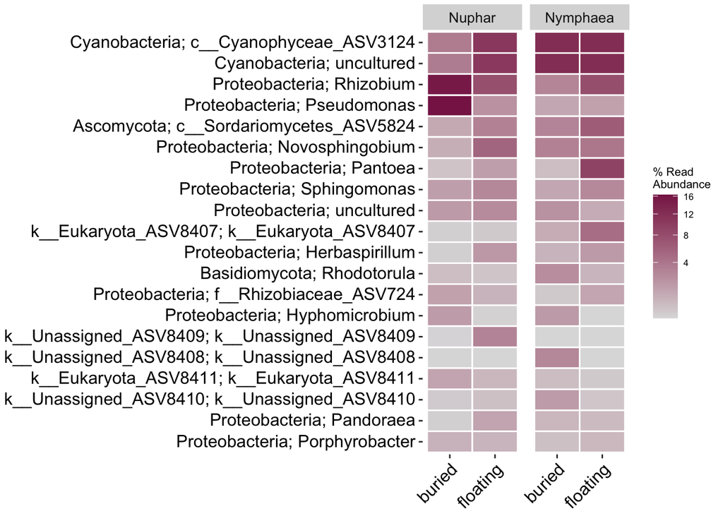

```r
familyheatmap <- amp_heatmap(d,
            group_by = "Location",
            facet_by = "plant",
            tax_aggregate = "Genus",
            tax_add = "Phylum",
            tax_show = 20,
            color_vector = c('#DDDDDD', '#882255'),
            plot_colorscale = "sqrt",
            plot_values = FALSE) +
  theme(axis.text.x = element_text(angle = 45, size=12, vjust = 1),
        axis.text.y = element_text(size=12),
        legend.position="right")
familyheatmap
```

```r
pdf("figures/familyHeatMap.pdf")
familyheatmap
dev.off()
```

There is also an option to make a heatmap with predicted functions

[figure not shown]

```r
functionHeatMap <- amp_heatmap(d,
            group_by = c("Location"),
            tax_aggregate = "Genus",
            plot_functions = TRUE,
            tax_show = 50,
            functions = c("Filamentous", "Chemoautotroph_mixotroph", "AOB", "NOB", "Aerobic heterotroph", "Nitrite reduction", "Sulfate reduction", "Fermentation", "Acetogen", "Short-chain fatty acids", "Sugars", "Proteins_amino acids"))
functionHeatMap
```

```r
pdf("figures/functionHeatMap.pdf", height = 10, width = 20)
functionHeatMap
dev.off()
```

It can be helpful to make the data into a phyloseq object for future analyses, but I am not very good with the phyloseq functions

```r
otu.table <- otu_table(otu.table, taxa_are_rows = TRUE)
tax.table <- tax_table(tax.table)
sam.data <- as.matrix(metadata)
sam.data <- sample_data(metadata)
rownames(sam.data) <- metadata$SampleID

ps <- phyloseq(otu.table, tax.table, sam.data)
random_tree = rtree(ntaxa(ps), rooted=TRUE, tip.label=taxa_names(ps))

ps = merge_phyloseq(ps,random_tree)
```

[output not shown]

[output not shown]

[output not shown]

[output not shown]

[output not shown]

[output not shown]

[output not shown]

[output not shown]

[output not shown]

[output not shown]

[output not shown]

[output not shown]

[output not shown]

[output not shown]

```r
ps <- subset_taxa(ps, kingdom !="Unassigned")
```

[output not shown]

[output not shown]

[output not shown]

[output not shown]

[output not shown]

[output not shown]

[output not shown]

```r
ps <- subset_taxa(ps, phylum != "NA")
```

[output not shown]

[output not shown]

[output not shown]

[output not shown]

[output not shown]

[output not shown]

[output not shown]

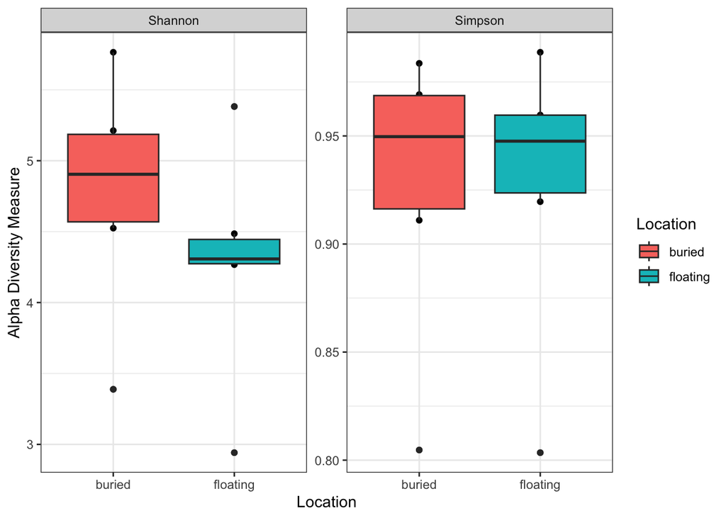

```r
plot_richness(ps, x="Location", measures=c("Shannon", "Simpson")) + geom_boxplot(aes(fill = Location)) + theme_bw()
```

Next, calculate richness and diversity and make more plots

Make a new dataframe with the ASVs from the pivot dataframe

```r
ASV <- pivot %>% dplyr::select(SampleID, otu, value) # the pivot dataframe also removed all the ASVs that were unassigned at the kingdom level
```

[output not shown]

```r
ASV <- ASV %>% pivot_wider(names_from = otu, values_from = value)
ASV[c(9:6831)] <- sapply(ASV[c(9:6831)],as.numeric)
ASV[c(9:6831)][is.na(ASV[c(9:6831)])] <- 0
ASV <- merge(metadata, ASV)
ASV.gp <- ASV %>% group_by(SampleID, Location, plant, treatment) %>% summarize_at(vars(ASV2507:ASV8786), sum)
```

Make vectors for richness

```r
nutop.rich <- specnumber((ASV.gp %>% filter(treatment == "NuTop"))[-c(1:4)])
nubot.rich <- specnumber((ASV.gp %>% filter(treatment == "NuBot"))[-c(1:4)])
nytop.rich <- specnumber((ASV.gp %>% filter(treatment == "NyTop"))[-c(1:4)])
nybot.rich <- specnumber((ASV.gp %>% filter(treatment == "NyBot"))[-c(1:4)])
```

Make vectors for diversity using the shannon index

```r
nutop.div <- vegan::diversity((ASV.gp %>% filter(treatment == "NuTop"))[-c(1:4)], index = "shannon")
nubot.div <- vegan::diversity((ASV.gp %>% filter(treatment == "NuBot"))[-c(1:4)], index = "shannon")
nytop.div <- vegan::diversity((ASV.gp %>% filter(treatment == "NyTop"))[-c(1:4)], index = "shannon")
nybot.div <- vegan::diversity((ASV.gp %>% filter(treatment == "NyBot"))[-c(1:4)],index = "shannon")
```

Make dataframe with diversity and richness vectors

```r
richness <- c(nubot.rich, nutop.rich, nybot.rich, nytop.rich)
diversity <- c(nubot.div, nutop.div, nybot.div, nytop.div)

rich.div <- data.frame(ASV.gp$Location, ASV.gp$plant, ASV.gp$treatment, richness, diversity)
```

STATISTICS TIME! Anovas to determine differences in richness and diversity

```r
set.seed(12345)
rich.lm <- lm(richness ~ ASV.gp.Location, data = rich.div)
rich.aov <- aov(rich.lm)
summary(rich.aov)# there is a difference in OTU richness
```

```
##                 Df  Sum Sq Mean Sq F value  Pr(>F)
## ASV.gp.Location  1 1962634 1962634   11.98 0.00611 **
## Residuals       10 1638460  163846
## ---
## Signif. codes:  0 '***' 0.001 '**' 0.01 '*' 0.05 '.' 0.1 ' ' 1
```

```r
div.lm <- lm(diversity ~ ASV.gp.Location, data = rich.div)
div.aov <- aov(div.lm)
summary(div.aov)# there is no difference in diversity
```

```
##                 Df Sum Sq Mean Sq F value Pr(>F)
## ASV.gp.Location  1  0.719  0.7186   1.144   0.31
## Residuals       10  6.283  0.6283
```

Richness plot

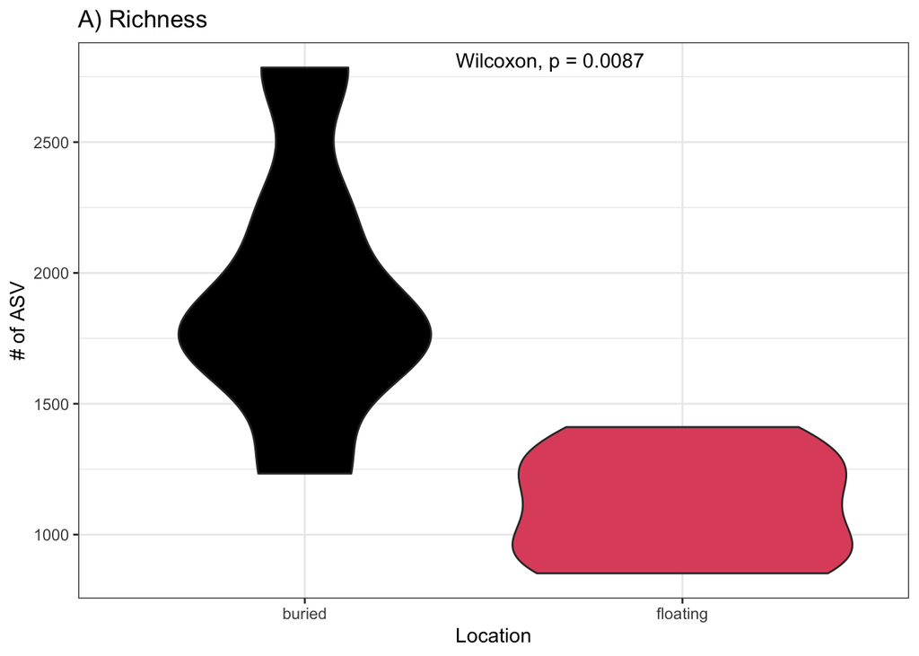

```r
richness.plot <- ggplot(data = rich.div, aes(x = ASV.gp.Location, y = richness, fill = ASV.gp.Location)) + geom_violin() + theme_bw() + theme(legend.position = "none") + theme(text=element_text(size=20)) + labs(y = "# of ASV", x = "Location") + theme(axis.text.x = element_text(angle = 45, vjust = 1, hjust=1)) + theme_bw() + theme(legend.position = "none") + ggtitle("A) Richness") + scale_fill_manual(values = pal) + stat_compare_means(label.x = 1.5)

richness.plot
```

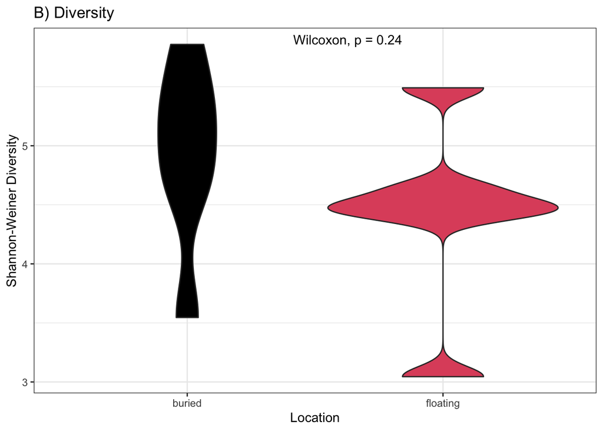

```r
diversity.plot <- ggplot(data = rich.div, aes(x = ASV.gp.Location, y = diversity, fill = ASV.gp.Location)) + geom_violin()+ theme(legend.position = "none") + theme(text=element_text(size=20)) + labs(y = "Shannon-Weiner Diversity", x = "Location") + theme(axis.text.x = element_text(angle = 45, vjust = 1, hjust=1)) + theme_bw() + theme(legend.position = "none") + ggtitle("B) Diversity") + scale_fill_manual(values = pal) + stat_compare_means(label.x = 1.5)
diversity.plot
```

```r
pdf("figures/richness_diversity.pdf")
richness.plot + diversity.plot
dev.off()
```

Richness and Diversity for Bacteria Only

```r
ASV.b <- pivot %>% filter(kingdom == "Bacteria") %>% dplyr::select(SampleID, otu, value) # the pivot dataframe also removed all the ASVs that were unassigned at the kingdom level
```

[output not shown]

```r
ASV.b <- ASV.b %>% pivot_wider(names_from = otu, values_from = value)
ASV.b[c(9:6191)] <- sapply(ASV.b[c(9:6191)],as.numeric)
ASV.b[c(9:6191)][is.na(ASV.b[c(9:6191)])] <- 0

ASV.b <- merge(metadata, ASV.b, by = "SampleID")

ASV.gp.b <- ASV.b %>% group_by(SampleID, Location, plant, treatment) %>% summarize_at(vars(ASV2:ASV6528), sum)
```

```r
nutop.rich <- specnumber((ASV.gp.b %>% filter(treatment == "NuTop"))[-c(1:11)])
nubot.rich <- specnumber((ASV.gp.b %>% filter(treatment == "NuBot"))[-c(1:11)])
nytop.rich <- specnumber((ASV.gp.b %>% filter(treatment == "NyTop"))[-c(1:11)])
nybot.rich <- specnumber((ASV.gp.b %>% filter(treatment == "NyBot"))[-c(1:11)])
```

```r
nutop.div <- vegan::diversity((ASV.gp.b %>% filter(treatment == "NuTop"))[-c(1:11)], index = "shannon")
nubot.div <- vegan::diversity((ASV.gp.b %>% filter(treatment == "NuBot"))[-c(1:11)], index = "shannon")
nytop.div <- vegan::diversity((ASV.gp.b %>% filter(treatment == "NyTop"))[-c(1:11)], index = "shannon")
nybot.div <- vegan::diversity((ASV.gp.b %>% filter(treatment == "NyBot"))[-c(1:11)],index = "shannon")
```

```r
richness.b <- c(nubot.rich, nutop.rich, nybot.rich, nytop.rich)
diversity.b <- c(nubot.div, nutop.div, nybot.div, nytop.div)

rich.div.b <- data.frame(ASV.gp.b$Location, ASV.gp.b$plant, ASV.gp.b$treatment, richness, diversity)
```

```r
set.seed(12345)
rich.lm.b <- lm(richness ~ ASV.gp.b.Location, data = rich.div.b)
rich.aov.b <- aov(rich.lm.b)
summary(rich.aov.b)# there is a difference in OTU richness
```

```
##                   Df  Sum Sq Mean Sq F value  Pr(>F)
## ASV.gp.b.Location  1 1962634 1962634   11.98 0.00611 **
## Residuals         10 1638460  163846
## ---
## Signif. codes:  0 '***' 0.001 '**' 0.01 '*' 0.05 '.' 0.1 ' ' 1
```

```r
div.lm.b <- lm(diversity ~ ASV.gp.b.Location, data = rich.div.b)
div.aov.b <- aov(div.lm.b)
summary(div.aov.b)# there is no difference in diversity
```

```
##                   Df Sum Sq Mean Sq F value Pr(>F)
## ASV.gp.b.Location  1  0.719  0.7186   1.144   0.31
## Residuals         10  6.283  0.6283
```

Richness and Diversity for Eukarya Only

```r
ASV.e <- pivot %>% filter(kingdom == "Eukaryota") %>% dplyr::select(SampleID, otu, value) # the pivot dataframe also removed all the ASVs that were unassigned at the kingdom level
```

[output not shown]

```r
ASV.e <- ASV.e %>% pivot_wider(names_from = otu, values_from = value)
ASV.e[c(9:603)] <- sapply(ASV.e[c(9:603)],as.numeric)
ASV.e[c(9:603)][is.na(ASV.e[c(9:603)])] <- 0

ASV.e <- merge(metadata, ASV.e, by = "SampleID")

ASV.gp.e <- ASV.e %>% group_by(SampleID, Location, plant, treatment) %>% summarize_at(vars(ASV2713:ASV8786), sum)
```

```r
nutop.rich <- specnumber((ASV.gp.e %>% filter(treatment == "NuTop"))[-c(1:11)])
nubot.rich <- specnumber((ASV.gp.e %>% filter(treatment == "NuBot"))[-c(1:11)])
nytop.rich <- specnumber((ASV.gp.e %>% filter(treatment == "NyTop"))[-c(1:11)])
nybot.rich <- specnumber((ASV.gp.e %>% filter(treatment == "NyBot"))[-c(1:11)])
```

```r
nutop.div <- vegan::diversity((ASV.gp.e %>% filter(treatment == "NuTop"))[-c(1:11)], index = "shannon")
nubot.div <- vegan::diversity((ASV.gp.e %>% filter(treatment == "NuBot"))[-c(1:11)], index = "shannon")
nytop.div <- vegan::diversity((ASV.gp.e %>% filter(treatment == "NyTop"))[-c(1:11)], index = "shannon")
nybot.div <- vegan::diversity((ASV.gp.e %>% filter(treatment == "NyBot"))[-c(1:11)],index = "shannon")
```

```r
richness.e <- c(nubot.rich, nutop.rich, nybot.rich, nytop.rich)
diversity.e <- c(nubot.div, nutop.div, nybot.div, nytop.div)

rich.div.e <- data.frame(ASV.gp.e$Location, ASV.gp.e$plant, ASV.gp.e$treatment, richness, diversity)
```

```r
set.seed(12345)
rich.lm.e <- lm(richness ~ ASV.gp.e.Location, data = rich.div.e)
rich.aov.e <- aov(rich.lm.e)
summary(rich.aov.e)# there is a difference in OTU richness
```

```
##                   Df  Sum Sq Mean Sq F value  Pr(>F)
## ASV.gp.e.Location  1 1962634 1962634   11.98 0.00611 **
## Residuals         10 1638460  163846
## ---
## Signif. codes:  0 '***' 0.001 '**' 0.01 '*' 0.05 '.' 0.1 ' ' 1
```

```r
div.lm.e <- lm(diversity ~ ASV.gp.e.Location, data = rich.div.e)
div.aov.e <- aov(div.lm.e)
summary(div.aov.e)# there is no difference in diversity
```

```
##                   Df Sum Sq Mean Sq F value Pr(>F)
## ASV.gp.e.Location  1  0.719  0.7186   1.144   0.31
## Residuals         10  6.283  0.6283
```

Another way to look at the data is using a venn diagram

```r
ASV.long <- pivot_longer(ASV.gp, cols = ASV2057:ASV8786, names_to = "ASV", values_to = "count")

y <- ASV.long %>% dplyr::select(Location, ASV, count)
Top = y %>% filter(Location == "floating")  %>% filter(count >0) %>% dplyr::select(ASV) #6038
Bottom = y %>% filter(Location == "buried")  %>% filter(count >0) %>% dplyr::select(ASV) #10128
y <- rbind(Top, Bottom)

Location <- c(rep("floating", 6038), rep("buried", 10128))

y$Location <- Location

x <- list(Top = y$ASV[1:6038], Bottom = y$ASV[6039:16166])
```

```r
pdf("figures/venndiagram.pdf")
ggvenn(
  x,
  fill_color = pal,
  stroke_size = 0.5, set_name_size = 4, show_percentage = TRUE
)
dev.off()
```

I also looked at indicator species, these are ASVs that are associated strongly with each treatment, the method uses nonlinear models to determine if ASVs are associated with certain treatment, this is more informational than just using ANOVAs to determine who is more abundant where

Make dataframe from OTU table

```r
pc = read.csv("/Users/briannepalmer/Library/CloudStorage/OneDrive-Personal/LeafFossilization/waterliliesOTU.csv", header = TRUE)
pc$otu <- counts_wtax$otu
```

Then, we only want to use the ASVs(OTUs) that are actually assigned at the phylum level, so to do that we will make a list of the OTUs that are assigned at the phylum level using the phyloseq object we created earlier (ps) – earlier I used the subset function to remove any ASVs that were assigned to phylum “NA”

```r
otu.assigned <- rownames(ps@otu_table)
pc <- pc %>% filter(otu %in% otu.assigned)
otu.names.ass <- pc$otu
pc<- pc[,-13] # remove otu name column
pc = t(pc) # transform
pc <- as.matrix(pc)
colnames(pc) <- otu.names.ass #otu names
pc <- as.data.frame(pc)
pc$Location <- as.vector(metadata$Location)
pc$plant <- metadata$plant
pc <- pc %>% dplyr::select(Location, plant, ASV1:ASV6370)
```

make abundance dataframe and vector for Location

```r
abund = pc[,3:ncol(pc)] # asvs only
location = pc$Location
```

run multipatt from the package indicspecies This takes a while to run, so run it once, save the output

```r
set.seed(12345) # this is necessary to get consistent resilts
inv = multipatt(abund, location, func = "r", control = how(nperm=9999), duleg = TRUE) #this uses the abundance of each ASVs and the Locations that they are associated with to show us what ASVs are indicators of each location. The "r" function is useful for finding ecologically relevant ASVs. See the developer's website for more details https://emf-creaf.github.io/indicspecies/articles/IndicatorSpeciesAnalysis.html
```

be wary of type 1 error, this occurs when you have a lot of ASVs (like we do) and results in false positives, therefore it is necessary to use an adjusted p-value

```r
ind.data<-inv$sign
#add adjusted p-value

ind.data <- rstatix::adjust_pvalue(ind.data, p.col = "p.value", output.col = "adj.p.value", method = "BH")
```

I had a lot more analyses planned for indicator species but, since nothing is significant with the adjusted p-value, I guess I have to move on.

instead, I can look for genera that are more abundant in each location, I already did this previously with phylum and class

```r
pivot.genus <- pivot %>% group_by(SampleID, genus) %>% dplyr::summarize(value = sum(value))
```

```r
genus <- pivot.genus %>% dplyr::select(SampleID, genus, value)
genus <- genus %>% pivot_wider(names_from = genus, values_from = value)
genus[c(2:771)] <- sapply(genus[c(2:771)],as.numeric)
genus[is.na(genus)] <- 0

genus <- merge(metadata, genus, by = "SampleID")
genus <- genus %>% dplyr::rename(NA. = `NA`)
genus.ggplot <- pivot_longer(genus, cols = `[Aquaspirillum]_polymorphum_group`:NA., names_to = "genus", values_to = "count")

set.seed(12345)
genus.anova <- genus.ggplot %>% group_by(genus) %>%
  do(broom::tidy(TukeyHSD(aov(count ~ Location, data = .)))) %>%
  ungroup

genus.anova.sig <- genus.anova %>% filter(adj.p.value < 0.05)
genus.anova.sig # 87
```

```
## # A tibble: 87 × 8
##    genus                term  contr…¹ null.…² estimate conf.low conf.h…³ adj.p…⁴
##    <chr>                <chr> <chr>     <dbl>    <dbl>    <dbl>    <dbl>   <dbl>
##  1 [Eubacterium]_copro… Loca… floati…       0 -3.27e-5 -6.55e-5 -5.30e-9 5.00e-2
##  2 67-14                Loca… floati…       0 -5.51e-5 -9.62e-5 -1.39e-5 1.38e-2
##  3 Actibacter           Loca… floati…       0 -1.18e-4 -2.14e-4 -2.15e-5 2.14e-2
##  4 ADurb.Bin063-1       Loca… floati…       0 -5.55e-5 -9.29e-5 -1.82e-5 7.81e-3
##  5 alphaI_cluster       Loca… floati…       0 -1.11e-4 -2.13e-4 -9.48e-6 3.51e-2
##  6 Anaerolineaceae      Loca… floati…       0 -1.35e-4 -2.42e-4 -2.89e-5 1.78e-2
##  7 Arenimonas           Loca… floati…       0 -6.12e-4 -8.89e-4 -3.36e-4 5.94e-4
##  8 Azorhizobium         Loca… floati…       0  3.73e-3  1.71e-4  7.28e-3 4.17e-2
##  9 Bacillus             Loca… floati…       0  1.51e-3  4.21e-5  2.98e-3 4.49e-2
## 10 Bacteroidetes_vadin… Loca… floati…       0 -7.81e-5 -1.48e-4 -7.93e-6 3.25e-2
## # … with 77 more rows, and abbreviated variable names ¹contrast, ²null.value,
## #   ³conf.high, ⁴adj.p.value
```

```r
significant.genera <- genus.anova.sig$genus
```

make column indicating if it is bottom or top

```r
top.genus <- genus.anova.sig %>% filter(estimate > 0) %>% dplyr::select(genus)
bottom.genus <- genus.anova.sig %>% filter(estimate < 0) %>% dplyr::select(genus)
```

new dataframe

```r
genus.sig <- pivot %>% filter(genus %in% significant.genera)
genus.sig.bottom <- genus.sig %>% filter(genus %in% bottom.genus$genus)
genus.sig.bottom$dominant <- rep("burried", times = nrow(genus.sig.bottom))
genus.sig.top <- genus.sig %>% filter(genus %in% top.genus$genus)
genus.sig.top$dominant <- rep("floating", times = nrow(genus.sig.top))
genus.sig <- rbind(genus.sig.top, genus.sig.bottom)
genus.sig <- merge(metadata, genus.sig, by = "SampleID")
```

make plots to show significant genera

```r
floating_summary <- genus.sig %>%
  filter(dominant == "floating") %>%
  group_by(Location, phylum, genus) %>%
  summarize(mean=mean(value),
            sd=sd(value))
```

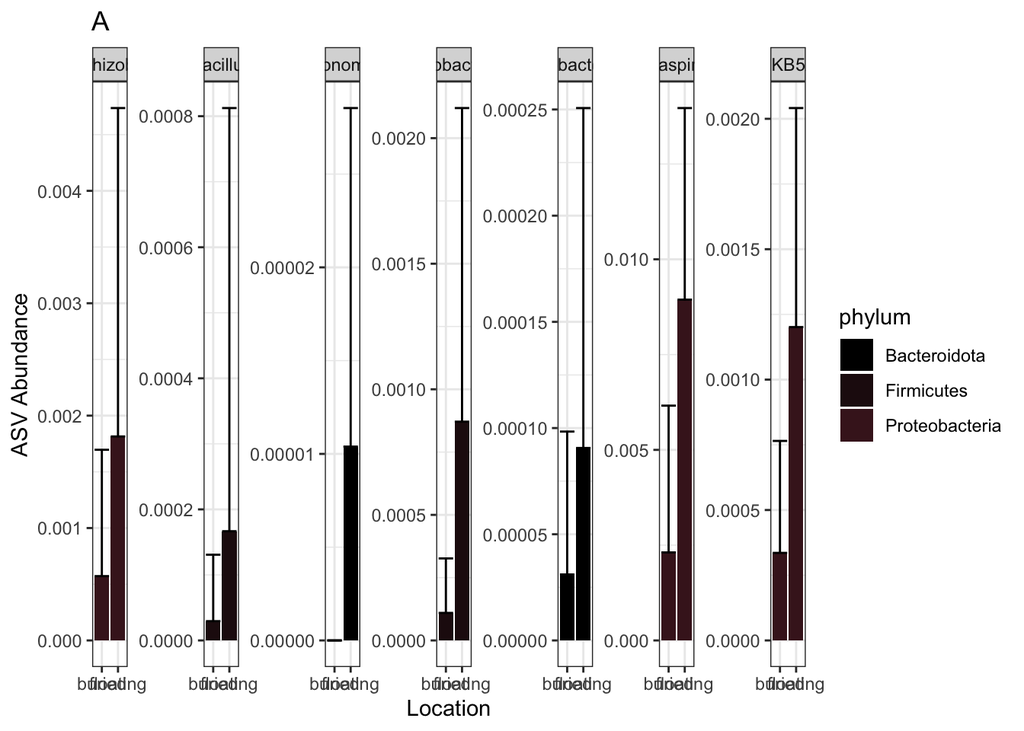

```r
floating <- ggplot(floating_summary) +
  geom_bar(aes(x = Location, y = mean, fill = phylum),
           stat = "identity",
           position = "dodge") +
  geom_errorbar(aes(x = Location, ymin = mean, ymax = mean+sd))+
  scale_fill_manual(values = largepal[1:3]) +
  labs(x = "Location", y = "ASV Abundance", title = "A") +
  theme_bw() + facet_wrap(. ~ genus, scales = "free", nrow = 1)

floating
```

```r
proteo.buried_summary <- genus.sig %>%
  filter(dominant == "burried", phylum == "Proteobacteria") %>%
  group_by(Location, class, genus) %>%
  summarize(mean=mean(value),
            sd=sd(value))
```

[figure not shown]

```r
proteo.buried <- ggplot(proteo.buried_summary) +
  geom_bar(aes(x = Location, y = mean, fill = class),
           stat = "identity",
           position = "dodge") +
  geom_errorbar(aes(x = Location, ymin = mean, ymax = mean+sd))+
  scale_fill_manual(values = largepal[4:6]) +
  labs(x = "Location", y = "ASV Abundance", title = "B") +
  theme_bw() + facet_wrap(.~genus, scales = "free", nrow = 3)

proteo.buried
```

```r
buried_summary <- genus.sig %>%
  filter(dominant == "burried", phylum != "Proteobacteria") %>%
  group_by(Location, phylum, genus) %>%
  summarize(mean=mean(value),
            sd=sd(value))
```

[figure not shown]

```r
buried <- ggplot(buried_summary) +
  geom_bar(aes(x = Location, y = mean, fill = phylum),
           stat = "identity",
           position = "dodge") +
  geom_errorbar(aes(x = Location, ymin = mean, ymax = mean+sd))+
  scale_fill_manual(values = largepal[7:24]) +
  labs(x = "Location", y = "ASV Abundance", title = "C") +
  theme_bw() + facet_wrap(.~genus, scales = "free", nrow = 6)

buried
```

```r
pdf("figures/significant_genera.pdf", height = 30, width = 20)
floating/proteo.buried/buried
dev.off()
```

this plot looks nice, but is probaby too big for a manuscript so I will make another one with phyla? or class?

```r
class.floating_summary <- genus.sig %>%
  filter(dominant == "floating") %>%
  group_by(Location, phylum, class) %>%
  summarize(mean=mean(value),
            sd=sd(value))
```

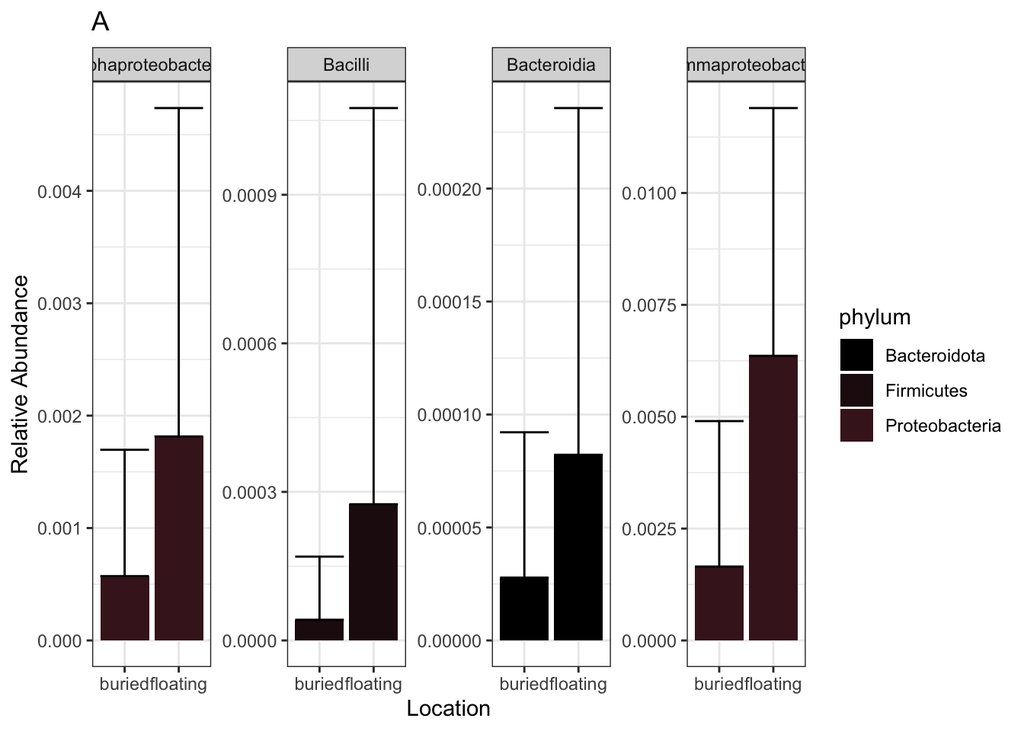

```r
class.floating <- ggplot(class.floating_summary) +
  geom_bar(aes(x = Location, y = mean, fill = phylum),
           stat = "identity",
           position = "dodge") +
  geom_errorbar(aes(x = Location, ymin = mean, ymax = mean+sd))+
  scale_fill_manual(values = largepal[1:3]) +
  labs(x = "Location", y = "Relative Abundance", title = "A") +
  theme_bw() + facet_wrap(. ~ class, scales = "free", nrow = 1)

class.floating
```

```r
class.buried_summary <- genus.sig %>%
  filter(dominant == "burried") %>%
  group_by(Location, phylum, class) %>%
  summarize(mean=mean(value),
            sd=sd(value))
```

[figure not shown]

```r
class.buried <- ggplot(class.buried_summary) +
  geom_bar(aes(x = Location, y = mean, fill = phylum),
           stat = "identity",
           position = "dodge") +
  geom_errorbar(aes(x = Location, ymin = mean, ymax = mean+sd))+
  scale_fill_manual(values = largepal[4:22]) +
  labs(x = "Location", y = "Relative Abundance", title = "B") +
  theme_bw() + facet_wrap(. ~ class, scales = "free", nrow = 4)

class.buried
```

```r
pdf("figures/significantgenusbyclass.pdf", height = 30, width = 20)
class.floating / class.buried
dev.off()
```

Now we can move onto the functions – for this I used Bugbase (phentype predictions) and PiCRUST2

Bugbase

```r
bugbase <- fread("/Users/briannepalmer/Library/CloudStorage/OneDrive-Personal/LeafFossilization/Leaf Fossilization Experiments_3_4_7_8/Experiment 7/BugBaseWaterLilies.csv")
```

```r
compare_means(Rel ~ Treatment, data = bugbase,
              group.by = "Function")
```

```
## # A tibble: 7 × 9
##   Function           .y.   group1 group2      p p.adj p.format p.signif method
##   <chr>              <chr> <chr>  <chr>   <dbl> <dbl> <chr>    <chr>    <chr>
## 1 Aerobic            Rel   Bottom Top    0.0260  0.18 0.026    *        Wilcoxon
## 2 Anaerobic          Rel   Bottom Top    0.0931  0.27 0.093    ns       Wilcoxon
## 3 FacultiveAnaerobic Rel   Bottom Top    0.158   0.27 0.158    ns       Wilcoxon
## 4 FormsBiofilm       Rel   Bottom Top    0.0411  0.21 0.041    *        Wilcoxon
## 5 GramNegative       Rel   Bottom Top    0.0898  0.27 0.090    ns       Wilcoxon
## 6 GramPositive       Rel   Bottom Top    0.0266  0.18 0.027    *        Wilcoxon
## 7 StressTolerant     Rel   Bottom Top    0.0411  0.21 0.041    *        Wilcoxon
```

```r
bugbase.plot <- bugbase %>% filter(Function != "GramPositive", Function != "GramNegative")

stat.test <- bugbase.plot %>%
  group_by(Function) %>%
  wilcox_test(Rel ~ Treatment) %>%
  adjust_pvalue(method = "bonferroni") %>%
  add_significance()
stat.test <- stat.test %>% add_xy_position(x = "Treatment")
```

```r
bug.plot <- ggboxplot(bugbase.plot, x = "Treatment", y = "Rel",
  facet.by = "Function", scales = "free", add = "jitter", fill = "Treatment") +
  stat_pvalue_manual(
    stat.test,
    label = "{p}"
    ) + scale_fill_manual(values = pal) + theme_bw() + theme(legend.position = "none")
```

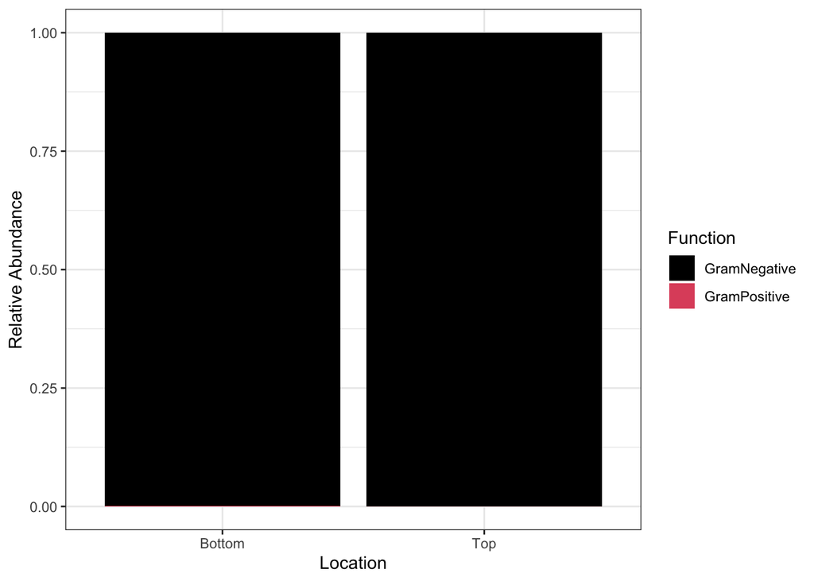

```r
gram <- ggplot(bugbase %>% filter(Function == c("GramNegative", "GramPositive")), aes(x = Treatment, y = Rel/3, fill= Function)) + geom_bar(stat = "identity", position = "stack") + theme_bw()+ labs(x= "Location", y = "Relative Abundance") + scale_fill_manual(values = pal)
gram
```

```r
pdf("figures/bugbase.pdf", height = 8, width = 12)
bug.plot
dev.off()
```

Now, onto PiCRUST2

for more details see the file called “picrust_waterlilies.R” – this is where I parsed a lot of the data and stored it in the data folder

```r
p2_PW <- "/Users/briannepalmer/Downloads/picrust2-2.5.1/picrust2_out_stratified/pathways_out/path_abun_unstrat.tsv.gz" # pathways
p2_KO <- "/Users/briannepalmer/Downloads/picrust2-2.5.1/picrust2_out_stratified/KO_metagenome_out/pred_metagenome_unstrat.tsv.gz" # KEGG
p2_EC <-"/Users/briannepalmer/Downloads/picrust2-2.5.1/picrust2_out_stratified/EC_metagenome_out/pred_metagenome_unstrat.tsv.gz"
sam_tab <- "/Users/briannepalmer/Library/CloudStorage/OneDrive-Personal/LeafFossilization/NymphaeaNuphar_18S/sample-metadata.csv" # metadata
```

```r
# imports PiCRUST data as phyloseq object
ps.pw <- import_picrust2(
  p2_PW,
  sam_tab,
  trait = "PATHWAY")

random_tree = rtree(ntaxa(ps.pw), rooted=TRUE, tip.label=taxa_names(ps.pw))
ps.pw = merge_phyloseq(ps.pw,random_tree)
```

[output not shown]

[output not shown]

[output not shown]

[output not shown]

[output not shown]

[output not shown]

[output not shown]

[output not shown]

```r
ps.pw@sam_data <- sample_data(metadata)
rownames(ps@sam_data) <- ps@sam_data$SampleID
colnames(ps@otu_table) <- ps@sam_data$SampleID
```

```r
wh0 = genefilter_sample(ps.pw, filterfun_sample(function(x) x > 5), A=0.5*nsamples(ps)) # removes low abundance pathways
GP1 = prune_taxa(wh0, ps.pw)
```

[output not shown]

[output not shown]

```r
GP1 = transform_sample_counts(GP1, function(x) 1E6 * x/sum(x))
```

[output not shown]

[output not shown]

[output not shown]

[output not shown]

[output not shown]

[output not shown]

[output not shown]

Ordnation

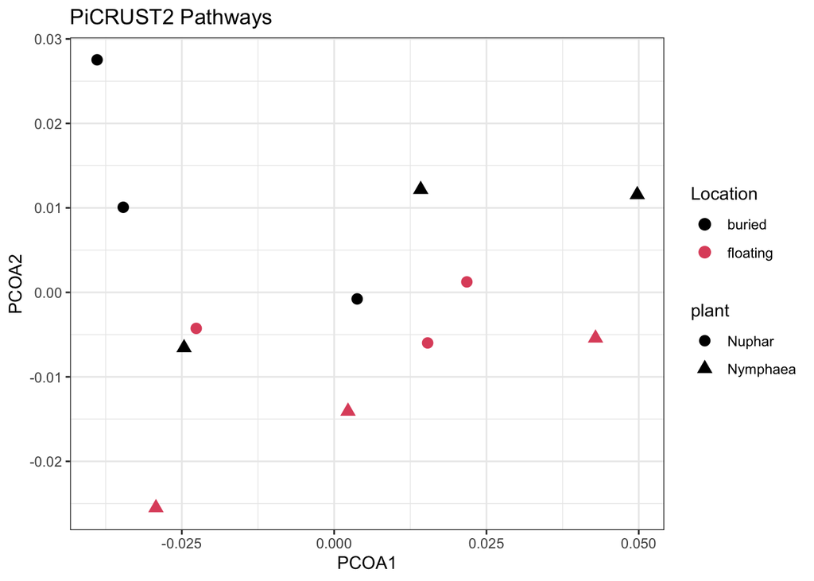

```r
ordu = ordinate(GP1, "PCoA", "unifrac", weighted=TRUE)
pw <- plot_ordination(GP1, ordu, color="Location", shape="plant") + theme_bw() + labs(x = "PCOA1", y = "PCOA2")  + geom_point(size =3) + ggtitle("PiCRUST2 Pathways") + scale_color_manual(values = pal)
pw
```

STATISTICS TIME! (PERMANOVA)

```r
set.seed(12345)
adonis2(phyloseq::distance(GP1, method="bray") ~ Location,
       data = metadata) # 0.352
```

```
## Permutation test for adonis under reduced model
## Terms added sequentially (first to last)
## Permutation: free
## Number of permutations: 999
##
## adonis2(formula = phyloseq::distance(GP1, method = "bray") ~ Location, data = metadata)
##          Df SumOfSqs      R2      F Pr(>F)
## Location  1 0.009028 0.08643 0.9461  0.352
## Residual 10 0.095419 0.91357
## Total    11 0.104446 1.00000
```

```r
adonis2(phyloseq::distance(GP1, method="bray") ~ plant,
        data = metadata) # 0.37
```

```
## Permutation test for adonis under reduced model
## Terms added sequentially (first to last)
## Permutation: free
## Number of permutations: 999
##
## adonis2(formula = phyloseq::distance(GP1, method = "bray") ~ plant, data = metadata)
##          Df SumOfSqs      R2      F Pr(>F)
## plant     1 0.009520 0.09115 1.0029   0.37
## Residual 10 0.094926 0.90885
## Total    11 0.104446 1.00000
```

There is not a difference in the composition of pathways between the locations. However, we can look for specific pathways that vary between locations

```r
p2PW = as.data.frame(fread(p2_PW))
rownames(p2PW) = p2PW$"pathway"
p2PW = as.matrix(p2PW[,-1])
# make relative abundance df
p2PW <-sweep(p2PW, 2, colSums(p2PW), `/`)
```

```r
pw <- t(p2PW)
pw <- cbind(metadata, pw)
pw.t <- pw %>% pivot_longer(cols = `1CMET2-PWY`:`VALSYN-PWY`, names_to = "pathway", values_to = "rel")

pw.anova <- pw.t %>% group_by(pathway) %>%
  do(broom::tidy(TukeyHSD(aov(rel ~ Location, data = .)))) %>%
  ungroup

pw.anova.sig <- pw.anova %>% filter(adj.p.value < 0.05) # 56 with p =0.05 but only 10 with p = 0.01
```

A lot of these pathways are not named easily so I had to look them up online. For this MS, I decided just to talk about the key pathways relating to nitrogen cycling and methanogensis – I might just focus on methanogenesis

```r
pw.sig <- pw.t %>% filter(pathway %in% pw.anova.sig$pathway)

pw.plot <- ggplot(pw.sig, aes(y = rel, x = Location, fill = Location)) + geom_boxplot() + theme(axis.text.x = element_text(size = 10)) + theme(legend.position = "right") + theme_bw() + theme(legend.position = "none") + scale_fill_manual(values = pal) + labs(x = "Location", y = "Relative Abundance") + facet_wrap(.~pathway, scales = "free")
```

```r
pdf("figures/pathwaysplot.pdf", height = 20, width = 20)
pw.plot
dev.off()
```